# HW6

Łukasz Lepianka

2022-12-30

## ggforce

“Ggforce” to pakiet rozszerzający możliwości ggplota, jak sam autor mówi, dostarczając narzędzia do tworzenia wykresów a la [D3.js](https://d3js.org). Pakiet daje nam możliwość stworzenia wielu nowych wykresów takich jak wykresy przepływu, wykresy pierścieniowe, diagramy Woroneja, a także daje nam on możliwość przybliżenia danej części wykresu czy zaznaczenia i oznaczenia danej grupy (pełna lista funkcji jest dostępna pod tym [linkiem](https://ggforce.data-imaginist.com/reference/index.html)).

Poniżej zwizualizowałem kilka z nich, korzystając z data setu ‘nycflights13’.

### Przykład 1

W tym przykładzie widać działanie funkcji geom_mark, która zaznacza wskazane grupy i przy okazji może je oznaczyć etykietami. W tym konkretnym przypadku korzystamy z zaznaczania prostokątami, ale pakiet daje nam też kilka innych możliwości np. elipsy.

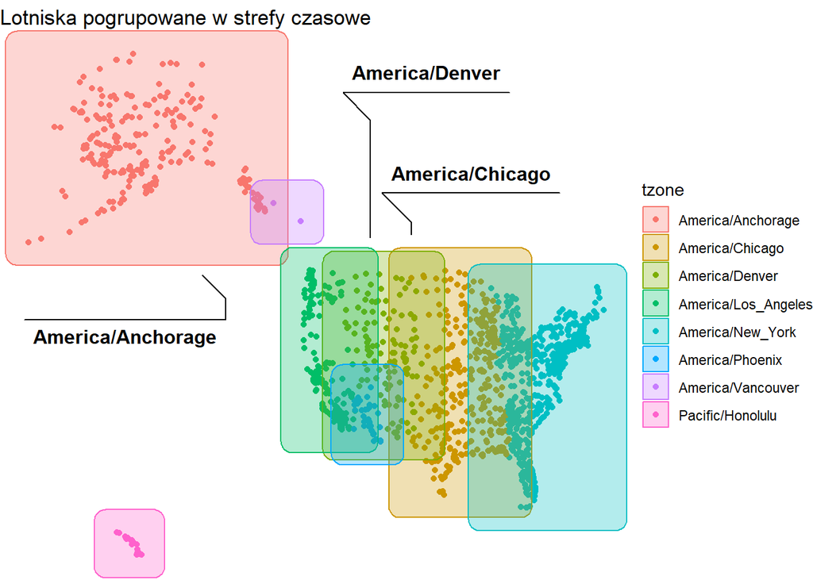

```r
library(dplyr)
library(ggplot2)
library(ggforce)
library(nycflights13)

airports %>%
  filter(lon < 0 & !is.na(tzone)) %>%
  ggplot(aes(x = lon, y = lat, col = tzone)) +
  geom_point() +
  geom_mark_rect(aes(fill = tzone, label = tzone)) +
  theme_void() +
  labs(title = "Lotniska pogrupowane w strefy czasowe")
```

### Przykład 2

W kolejnym przykładzie wykorzystamy funkcje geom_voronoi_tile i geom_voronoi_segment do zwizualizowania diagramów Woroneja, czyli diagramów dzielących płaszczyznę na n obszarów, w taki sposób, że każdy punkt w dowolnym obszarze znajduje się bliżej określonego punktu ze zbioru n punktów, niż od pozostałych n-1 punktów.

Poniżej zwizualizowane jest kilka przykładów pokazujących rozbicie mapy na obszary, w których do danego lotniska jest najbliżej.

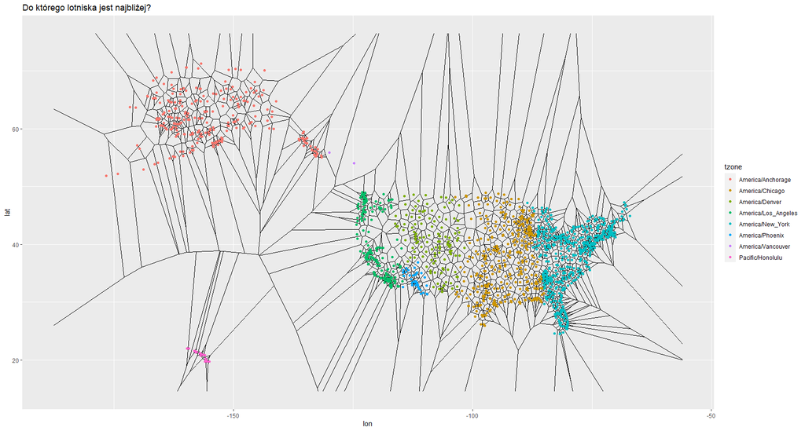

```r
airports %>%
  filter(lon < 0 & !is.na(tzone)) %>%
  ggplot(aes(x = lon, y = lat, group = -1L)) +
  geom_voronoi_segment() +
  geom_point(aes(col = tzone))+
  labs(title = "Do którego lotniska jest najbliżej?")
```

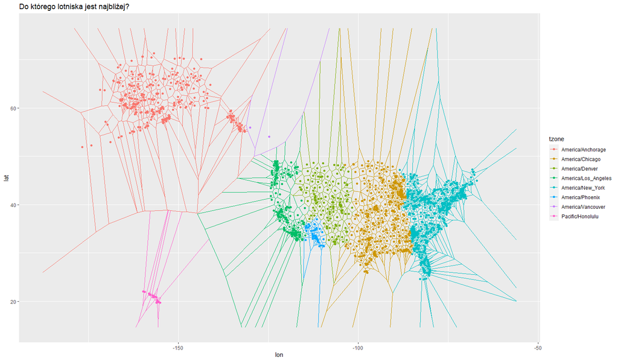

```r
airports %>%
  filter(lon < 0 & !is.na(tzone)) %>%
  ggplot(aes(x = lon, y = lat,col = tzone, group = -1L)) +
  geom_voronoi_segment() +
  geom_point() +
  labs(title = "Do którego lotniska jest najbliżej?")
```

W geom_voronoi_tile() możemy ustawić dodatkowo wypełnienie i maksymalny promień od punktu, czego nie można zrobić funkcją geom_voronoi_segment().

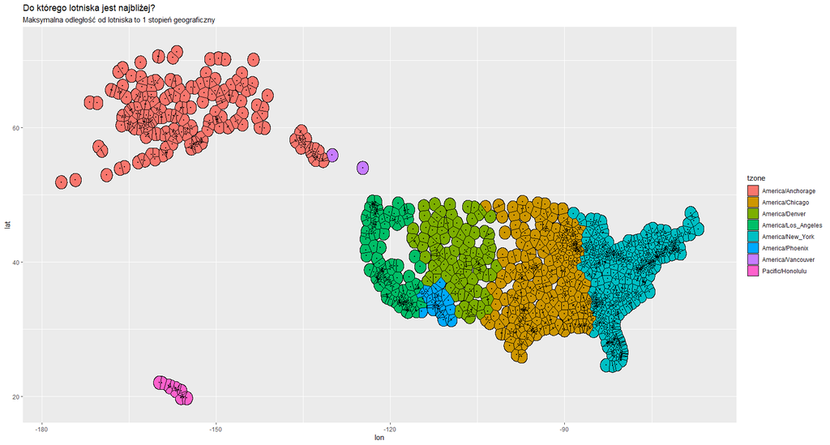

```r
airports %>%
  filter(lon < 0 & !is.na(tzone)) %>%
  ggplot(aes(x = lon, y = lat, group = -1L)) +
  geom_voronoi_tile(aes(fill = tzone), col = 'black', max.radius = 1) +
  geom_point(size = 0.5) +
  labs(title = "Do którego lotniska jest najbliżej?",
       subtitle = "Maksymalna odległość od lotniska to 1 stopień geograficzny")
```

Oczywiście na powyższych wykresach niewiele widać, dlatego można zastosować przybliżenie (funkcję facet_zoom). Przybliżmy, więc strefę czasową Phoenix:

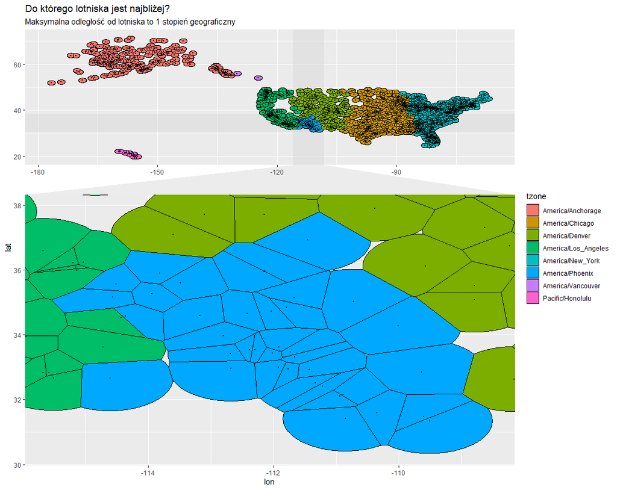

```r
airports %>%
  filter(lon < 0 & !is.na(tzone)) %>%
ggplot(aes(x = lon, y = lat, group = -1L)) +
  geom_voronoi_tile(aes(fill = tzone), col = 'black', max.radius = 1) +
  geom_point(size = 0.5) +
  facet_zoom(xy = tzone == 'America/Phoenix', horizontal = FALSE)+
  labs(title = "Do którego lotniska jest najbliżej?",
       subtitle = "Maksymalna odległość od lotniska to 1 stopień geograficzny")
```

## Podsumowanie

Ggforce daje dostęp do rysowania wielu nowych wymyślnych kształtów, a także pomaga przy zaznaczaniu grup i eksponowaniu tych części wykresu, na którym nam zależy.